# Тесты на стационарность.

**Временные ряды** отличаются от более традиционных задач моделирования классификации и регрессионного прогнозирования. Временная структура вносит порядок в наблюдения. Этот навязанный порядок означает, что важные предположения о непротиворечивости этих наблюдений должны обрабатываться особым образом.

Например, при моделировании существуют допущения о непротиворечивости сводной статистики наблюдений. В терминологии временных рядов мы называем это ожидание **стационарным временным рядом**.

Эти допущения могут быть легко нарушены во временных рядах добавлением тренда, сезонности и других структур, зависящих от времени.

В этом уроке мы рассмотрим, как проверить, является ли ваш временной ряд стационарным с помощью Python.

## Стационарный временной ряд

Наблюдения в **стационарном временном ряду** не зависят от времени.

Временные ряды являются стационарными, если они не имеют трендовых или сезонных эффектов. Сводные статистические данные, рассчитанные для временных рядов, непротиворечивы во времени, как среднее значение или дисперсия наблюдений.

Когда временной ряд является стационарным, его проще моделировать. Методы статистического моделирования предполагают или требуют, чтобы временные ряды были стационарными.

Загрузим набор данных daily-total-female-births.csv.

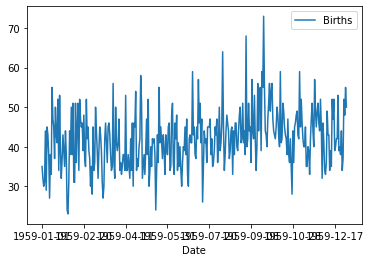

```python
from pandas import read_csv
from matplotlib import pyplot
from urllib.request import urlretrieve

urlretrieve('https://github.com/SerjiEvg/data-analysis/raw/main/data/daily-total-female-births.csv', 'daily-total-female-births.csv')
series = read_csv('daily-total-female-births.csv', header=0, index_col=0)
series.plot()
pyplot.show()
```

## Нестационарные временные ряды

Наблюдения за **нестационарными временными рядами** показывают сезонные эффекты, тренды и другие структуры, зависящие от временного индекса.

Сводные статистические данные, такие как среднее значение и дисперсия, со временем меняются, что приводит к дрейфу в концепциях, которые модель может попытаться зафиксировать.

Классические методы анализа временных рядов и прогнозирования направлены на то, чтобы сделать нестационарные данные временных рядов стационарными путем выявления и устранения тенденций и устранения сезонных эффектов.

Загрузим набор данных airline-passengers.csv.

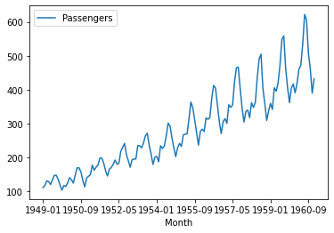

```python
from pandas import read_csv
from matplotlib import pyplot
from urllib.request import urlretrieve

urlretrieve('https://github.com/SerjiEvg/data-analysis/raw/main/data/airline-passengers.csv', 'airline-passengers.csv')
series = read_csv('airline-passengers.csv', header=0, index_col=0)
series.plot()
pyplot.show()
```

## Типы стационарных временных рядов

Понятие **стационарности** исходит из теоретического изучения временных рядов и является полезной абстракцией при прогнозировании.

Есть некоторые более тонкие понятия стационарности, с которыми можно столкнуться, если углубиться в эту тему:

- **Стационарный процесс**: Процесс, который генерирует стационарный ряд наблюдений.
- **Стационарная модель**: Модель, описывающая стационарный ряд наблюдений.
- **Стационарный тренд**: временной ряд, не демонстрирующий тренда.
- **Сезонный стационарный**: временной ряд, который не проявляет сезонности.
- **Строго стационарный**: математическое определение стационарного процесса, в частности, что совместное распределение наблюдений инвариантно к сдвигу во времени.

## Проверки на стационарность

Существует множество методов проверки того, является ли временной ряд (прямые наблюдения, остатки и т.д.) **стационарным** или **нестационарным**.

- **Посмотреть на графики**: просмотреть график временных рядов данных и визуально проверить, есть ли какие-либо очевидные тенденции или сезонность.
- **Сводная статистика**: просмотреть сводную статистику для своих данных по сезонам или случайным разделам и проверить наличие очевидных или существенных различий.
- **Статистические тесты**: использовать статистические тесты, чтобы проверить, выполняются ли ожидания стационарности или были нарушены.

Мы уже представили наборы данных **Daily Female Births** и **Airline Passengers** как стационарные и нестационарные, соответственно, с графиками, показывающими очевидное отсутствие и присутствие компонентов тренда и сезонности.

Далее мы рассмотрим быстрый и грязный способ расчета и просмотра сводной статистики по нашему набору данных временных рядов, чтобы проверить, является ли он стационарным.

## Сводные статистические данные

Быстрая и грубая проверка, чтобы увидеть, является ли временной ряд нестационарным — это просмотреть **сводную статистику**.

Временной ряд можно разделить на две (или более) частей и сравнить среднее значение и дисперсию каждой части. Если они различаются и разница статистически значима, временной ряд, вероятно, нестационарен.

Далее давайте попробуем этот подход на наборе данных **Daily Female Births**.

### Набор данных о ежедневных рождениях

Поскольку мы смотрим на среднее значение и дисперсию, мы предполагаем, что данные соответствуют распределению Гаусса.

Мы также можем быстро проверить это, взглянув на гистограмму наших наблюдений.

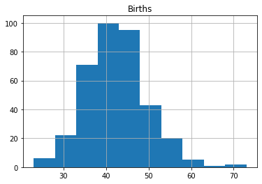

```python
from pandas import read_csv
from matplotlib import pyplot
series = read_csv('daily-total-female-births.csv', header=0, index_col=0)
series.hist()
pyplot.show()
```

При выполнении примера строится гистограмма значений из временного ряда. Мы ясно видим колоколообразную форму распределения Гаусса, возможно, с более длинным правым хвостом.

Затем мы можем разделить временной ряд на две смежные последовательности. Затем мы можем вычислить среднее значение и дисперсию каждой группы чисел и сравнить значения.

```python
from pandas import read_csv
series = read_csv('daily-total-female-births.csv', header=0, index_col=0)
X = series.values
split = round(len(X) / 2)
X1, X2 = X[0:split], X[split:]
mean1, mean2 = X1.mean(), X2.mean()
var1, var2 = X1.var(), X2.var()
print('среднее 1=%f, среднее 2=%f' % (mean1, mean2))
print('дисперсия 1=%f, дисперсия 2=%f' % (var1, var2))
```

```
среднее 1=39.763736, среднее 2=44.185792
дисперсия 1=49.213410, дисперсия 2=48.708651
```

Выполнение этого примера показывает, что средние значения и значения дисперсии различны, но находятся в одном и том же приблизительном диапазоне.

Давайте попробуем тот же трюк с набором данных **Airline Passengers**.

### Набор данных о пассажирах авиакомпаний

Переходя прямо к делу, мы можем разделить наш набор данных и вычислить среднее значение и дисперсию для каждой группы.

```python
from pandas import read_csv
series = read_csv('airline-passengers.csv', header=0, index_col=0)
X = series.values
split = round(len(X) / 2)
X1, X2 = X[0:split], X[split:]
mean1, mean2 = X1.mean(), X2.mean()
var1, var2 = X1.var(), X2.var()
print('среднее 1=%f, среднее 2=%f' % (mean1, mean2))
print('дисперсия 1=%f, дисперсия 2=%f' % (var1, var2))
```

```
среднее 1=182.902778, среднее 2=377.694444
дисперсия 1=2244.087770, дисперсия 2=7367.962191
```

Запустив пример, мы видим, что среднее значение и дисперсия выглядят очень по-разному.

У нас есть нестационарный временной ряд.

Давайте сделаем один шаг назад и проверим, имеет ли смысл предположение о распределении Гаусса в этом случае, построив значения временного ряда в виде гистограммы.

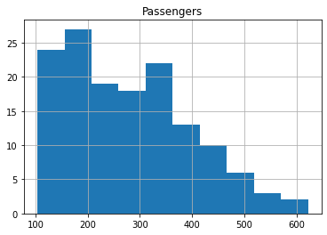

```python
from pandas import read_csv
from matplotlib import pyplot
series = read_csv('airline-passengers.csv', header=0, index_col=0)
series.hist()
pyplot.show()
```

Выполнение примера показывает, что действительно распределение значений не похоже на гауссово, поэтому значения среднего значения и дисперсии менее значимы. Это сжатое распределение наблюдений может быть еще одним индикатором нестационарного временного ряда.

Снова просмотрев график временного ряда, мы видим, что присутствует явная сезонная составляющая, и похоже, что сезонная составляющая нарастает.

Это может свидетельствовать об экспоненциальном росте от сезона к сезону. Логарифмическое преобразование можно использовать для выравнивания экспоненциального изменения обратно к линейной зависимости.

Ниже представлена та же гистограмма с логарифмическим преобразованием временного ряда.

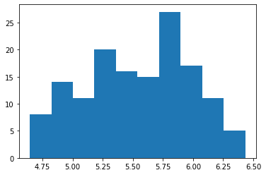

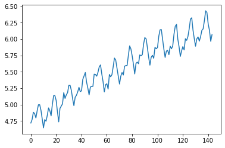

```python
from pandas import read_csv
from matplotlib import pyplot
from numpy import log
series = read_csv('airline-passengers.csv', header=0, index_col=0)
X = series.values
X = log(X)
pyplot.hist(X)
pyplot.show()
pyplot.plot(X)
pyplot.show()
```

Мы также создаем линейный график логарифмически преобразованных данных и видим, что экспоненциальный рост кажется уменьшенным, но у нас все еще есть тренд и сезонные элементы.

Теперь мы можем рассчитать среднее значение и стандартное отклонение значений логарифмически преобразованного набора данных.

```python
from pandas import read_csv
from matplotlib import pyplot
from numpy import log
series = read_csv('airline-passengers.csv', header=0, index_col=0)
X = series.values
X = log(X)
split = round(len(X) / 2)
X1, X2 = X[0:split], X[split:]
mean1, mean2 = X1.mean(), X2.mean()
var1, var2 = X1.var(), X2.var()
print('средний 1=%f, средний 2=%f' % (mean1, mean2))
print('дисперсия 1=%f, дисперсия 2=%f' % (var1, var2))
```

[output not shown]

Выполнение примеров показывает средние значения и значения стандартного отклонения для каждой группы, которые снова похожи, но не идентичны. Возможно, только по этим числам мы бы сказали, что временной ряд является стационарным, но мы твердо убеждены, что это не так, если рассматривать линейный график.

Это быстрый и грубый метод легко обмануть.

Мы можем использовать статистический тест, чтобы проверить, является ли разница между двумя выборками гауссовых случайных величин реальной или статистической случайностью. Мы могли бы изучить тесты статистической значимости, такие как t-критерий Стьюдента, но все становится сложнее из-за последовательной корреляции между значениями.

В следующем разделе мы будем использовать статистический тест, предназначенный для явного комментирования того, является ли одномерный временной ряд стационарным.

### Расширенный тест Дики-Фуллера

Статистические тесты делают серьезные предположения о ваших данных. Их можно использовать только для информирования о степени, в которой нулевая гипотеза может быть отклонена или не может быть отклонена. Чтобы данная проблема имела смысл, результат должен быть интерпретирован.

Тем не менее, они могут обеспечить быструю проверку и подтверждение того, что ваш временной ряд является стационарным или нестационарным.

Расширенный тест Дики-Фуллера — это тип статистического теста, называемый тестом на единичный корень .

Интуиция, стоящая за тестом единичного корня, заключается в том, что он определяет, насколько сильно временной ряд определяется тенденцией.

Существует ряд тестов на единичный корень, и расширенный тест Дики-Фуллера может быть одним из наиболее широко используемых. Он использует авторегрессионную модель и оптимизирует информационный критерий по нескольким различным значениям задержки.

Нулевая гипотеза теста состоит в том, что временной ряд может быть представлен единичным корнем, что он не является стационарным (имеет некоторую структуру, зависящую от времени). Альтернативная гипотеза (отвергающая нулевую гипотезу) состоит в том, что временной ряд является стационарным.

Нулевая гипотеза (H0) : если ее не удалось отвергнуть, она предполагает, что временной ряд имеет единичный корень, что означает, что он нестационарен. Он имеет некоторую временную структуру. Альтернативная гипотеза (H1) : нулевая гипотеза отвергается; это предполагает, что временной ряд не имеет единичного корня, что означает, что он является стационарным. Он не имеет временной структуры. Мы интерпретируем этот результат, используя p-значение из теста. Значение p ниже порога (например, 5% или 1%) предполагает, что мы отвергаем нулевую гипотезу (стационарную), в противном случае значение p выше порога предполагает, что мы не можем отвергнуть нулевую гипотезу (нестационарная).

p-значение > 0,05 : не удалось отвергнуть нулевую гипотезу (H0), данные имеют единичный корень и нестационарны. p-value <= 0,05 : Отклонить нулевую гипотезу (H0), данные не имеют единичного корня и являются стационарными. Ниже приведен пример расчета расширенного теста Дики-Фуллера в наборе данных Daily Female Births. Библиотека statsmodels предоставляет функцию adfuller() , реализующую тест.

```python
from pandas import read_csv
from statsmodels.tsa.stattools import adfuller
series = read_csv('daily-total-female-births.csv', header=0, index_col=0, squeeze=True)
X = series.values
result = adfuller(X)
print('ADF Statistic: %f' % result[0])
print('p-value: %f' % result[1])
print('Critical Values:')
for key, value in result[4].items():
	print('\t%s: %.3f' % (key, value))
```

[output not shown]

Отказ от нулевой гипотезы означает, что процесс не имеет единичного корня, и, в свою очередь, временной ряд является стационарным или не имеет зависящей от времени структуры.

Мы можем выполнить тот же тест на наборе данных Airline Passenger.

```python
from pandas import read_csv
from statsmodels.tsa.stattools import adfuller
series = read_csv('international-airline-passengers.csv', header=0, index_col=0, squeeze=True)
X = series.values
result = adfuller(X)
print('ADF Statistic: %f' % result[0])
print('p-value: %f' % result[1])
print('Critical Values:')
for key, value in result[4].items():
	print('\t%s: %.3f' % (key, value))
```

[output not shown]

Давайте снова преобразуем набор данных в журнал, чтобы сделать распределение значений более линейным и лучше соответствовать ожиданиям этого статистического теста.

```python
from pandas import read_csv
from statsmodels.tsa.stattools import adfuller
from numpy import log
series = read_csv('international-airline-passengers.csv', header=0, index_col=0, squeeze=True)
X = series.values
X = log(X)
result = adfuller(X)
print('ADF Statistic: %f' % result[0])
print('p-value: %f' % result[1])
for key, value in result[4].items():
	print('\t%s: %.3f' % (key, value))
```

[output not shown]